# Covid-19 Data Analysis Report

2023-02-11

## Library Requirements

Install these packages before running the codes.

```r
library(tidyverse)
library(dplyr)
library(lubridate)
library(ggplot2)
library(ggstatsplot)
library(ggside)
```

## Data Import

I will start by reading in the data from the four main Covid-19 csv files, and one extra csv file for US states’ areas for the purpose of data modelling later on.

```r
url_in <- "https://raw.githubusercontent.com/CSSEGISandData/COVID-19/master/csse_covid_19_data/csse_covid_19_time_series/"
file_names <- c("time_series_covid19_confirmed_US.csv","time_series_covid19_deaths_US.csv",
"time_series_covid19_confirmed_global.csv","time_series_covid19_deaths_global.csv")
urls <- str_c(url_in,file_names)

url_in2 <- "https://raw.githubusercontent.com/jakevdp/data-USstates/b9c5dfaf9530ac3fcab6bfee86aa2f3f6d4e8bea/"
file_names2 <- "state-areas.csv"
urls2 <- str_c(url_in2,file_names2)
```

Let’s read in the data and see what we have.

```r
global_cases <- read_csv(urls[3])
global_deaths <- read_csv(urls[4])
US_cases <- read_csv(urls[1])
US_deaths <- read_csv(urls[2])
US_state_area <- read_csv(urls2[1])
```

After looking at global_cases and global deaths, I would like to tidy those datasets and put each variable (date, cases, deaths) in their own column. Also, I don’t need Lat and Long for the analysis I am planning, so I will delete those and rename Region and State to be more R friendly.

```r
global_cases <- global_cases %>%
  pivot_longer(cols=-c('Province/State','Country/Region',Lat,Long),
               names_to="date",values_to="cases") %>%
  select(-c(Lat,Long))

global_deaths <- global_deaths %>%
  pivot_longer(cols=-c('Province/State','Country/Region',Lat,Long),
               names_to="date",values_to="deaths") %>%
  select(-c(Lat,Long))

global <- global_cases %>%
  full_join(global_deaths) %>%
  rename(Country_Region='Country/Region',Province_State='Province/State') %>%
  mutate(date=mdy(date))

global <- global %>% filter(cases > 0)

US_cases <- US_cases %>%
  pivot_longer(cols=-(UID:Combined_Key),
               names_to="date",
               values_to="cases") %>%
  select(Admin2:cases) %>%
  mutate(date=mdy(date)) %>%
  select(-c(Lat, Long_))

US_deaths <- US_deaths %>%
  pivot_longer(cols=-(UID:Population),
               names_to="date",
               values_to="deaths") %>%
  select(Admin2:deaths) %>%
  mutate(date=mdy(date)) %>%
  select(-c(Lat, Long_))

US <- US_cases %>%
  full_join(US_deaths)

global <- global %>%
  unite("Combined_Key",
        c(Province_State, Country_Region),
        sep=", ",
        na.rm = TRUE,
        remove = FALSE)
#Look up for population information on John Hopkins

uid_lookup_url <- "https://raw.githubusercontent.com/CSSEGISandData/COVID-19/master/csse_covid_19_data/UID_ISO_FIPS_LookUp_Table.csv"

#Then join the population data with the Global data-set
uid <- read_csv(uid_lookup_url) %>%
  select(-c(Lat, Long_, Combined_Key, code3, iso2, iso3, Admin2))
global <- global %>%
  left_join(uid, by = c("Province_State", "Country_Region")) %>%
  select(-c(UID, FIPS)) %>%
  select(Province_State, Country_Region, date, cases, deaths, Population, Combined_Key)

#Prepare the data by US states
US_by_state <- US %>%
  group_by(Province_State, Country_Region, date) %>%
  summarize(cases=sum(cases), deaths=sum(deaths),
            Population=sum(Population)) %>%
  mutate(deaths_per_mill=deaths*1000000/Population) %>%
  select(Province_State, Country_Region, date,
         cases, deaths, deaths_per_mill, Population) %>%
  ungroup()

#Prepare the data for US totals
US_totals <- US_by_state %>%
  group_by(Country_Region, date) %>%
  summarize(cases = sum(cases), deaths = sum (deaths), Population = sum(Population)) %>%
  mutate(deaths_per_mill = deaths *1000000 / Population) %>%
  select(Country_Region, date, cases, deaths, deaths_per_mill, Population) %>%
  ungroup()

#Prepare data for new cases and new deaths
US_by_state <- US_by_state %>%
  mutate(new_cases = cases - lag(cases),
         new_deaths = deaths - lag(deaths))
US_totals <- US_totals %>%
  mutate(new_cases = cases - lag (cases),
         new_deaths = deaths - lag (deaths))
tail(US_totals %>% select(new_cases, new_deaths, everything()))
```

```
## # A tibble: 6 × 8
##   new_cases new_deaths Country_Region date          cases deaths death…¹ Popul…²
##       <dbl>      <dbl> <chr>          <date>        <dbl>  <dbl>   <dbl>   <dbl>
## 1      4281         30 US             2023-02-11   1.03e8 1.11e6   3348.  3.33e8
## 2      2491          6 US             2023-02-12   1.03e8 1.11e6   3348.  3.33e8
## 3     21556        168 US             2023-02-13   1.03e8 1.11e6   3349.  3.33e8
## 4     46831        445 US             2023-02-14   1.03e8 1.12e6   3350.  3.33e8
## 5     87176        575 US             2023-02-15   1.03e8 1.12e6   3352.  3.33e8
## 6     59274       1071 US             2023-02-16   1.03e8 1.12e6   3355.  3.33e8
## # … with abbreviated variable names ¹deaths_per_mill, ²Population
```

```r
#Prepare data for top states impacted
US_state_totals <- US_by_state %>%
  group_by (Province_State) %>%
  summarize (deaths = max(deaths), cases = max(cases), population = max (Population),
             cases_per_thou = 1000 * cases / population,
             deaths_per_thou = 1000 * deaths / population) %>%
  filter (cases > 0, population > 0)

min_states <- US_state_totals %>%
  slice_min(deaths_per_thou, n=13)
max_states <- US_state_totals %>%
  slice_max(deaths_per_thou, n=10)

#Prepare for data modelling to explore the relationship between population density and fatality rate

colnames(US_state_area)[1] ="Province_State"
US_state_totals2 <- inner_join(US_state_totals, US_state_area,
           by = "Province_State")
US_state_totals3 <- US_state_totals2 %>%
  group_by (Province_State) %>%
  summarize(deaths_per_thou,pop_dens=population/`area (sq. mi)`,
            log_pop_dens=log(population/`area (sq. mi)`)) #Log transformation is required for this regression

## Data modelling
mod2 <- lm(deaths_per_thou ~ log_pop_dens, data = US_state_totals3)
summary(mod2)
```

```
##
## Call:
## lm(formula = deaths_per_thou ~ log_pop_dens, data = US_state_totals3)
##
## Residuals:
##     Min      1Q  Median      3Q     Max
## -1.9639 -0.6551  0.1631  0.7325  1.2811
##
## Coefficients:
##               Estimate Std. Error t value Pr(>|t|)
## (Intercept)   3.266584   0.402944   8.107 1.14e-10 ***
## log_pop_dens -0.003249   0.083262  -0.039    0.969
## ---
## Signif. codes:  0 '***' 0.001 '**' 0.01 '*' 0.05 '.' 0.1 ' ' 1
##
## Residual standard error: 0.8991 on 50 degrees of freedom
## Multiple R-squared:  3.046e-05,  Adjusted R-squared:  -0.01997
## F-statistic: 0.001523 on 1 and 50 DF,  p-value: 0.969
```

```r
min_states_dens <- US_state_totals3 %>%
  slice_min(log_pop_dens, n=10)
max_states_dens <- US_state_totals3 %>%
  slice_max(log_pop_dens, n=10)

x_grid2 <- seq(0,10)
new_df2 <- tibble(cases_per_thou = x_grid2)
US_state_totals3 %>% mutate(pred=predict(mod2))
```

```
## # A tibble: 52 × 5
##    Province_State       deaths_per_thou pop_dens log_pop_dens  pred
##    <chr>                          <dbl>    <dbl>        <dbl> <dbl>
##  1 Alabama                         4.26    93.5         4.54   3.25
##  2 Alaska                          1.99     1.13        0.121  3.27
##  3 Arizona                         4.53    63.8         4.16   3.25
##  4 Arkansas                        4.29    56.7         4.04   3.25
##  5 California                      2.55   241.          5.49   3.25
##  6 Colorado                        2.45    55.3         4.01   3.25
##  7 Connecticut                     3.39   643.          6.47   3.25
##  8 Delaware                        3.40   498.          6.21   3.25
##  9 District of Columbia            2.02 10379.          9.25   3.24
## 10 Florida                         3.99   327.          5.79   3.25
## # … with 42 more rows
```

```r
US_tot_w_pred2 <- US_state_totals3 %>% mutate(pred = predict(mod2))
```

## Data Summary

Below is an overview of the dataset.

```r
summary(US_totals)
```

```
##  Country_Region          date                cases               deaths
##  Length:1122        Min.   :2020-01-22   Min.   :        1   Min.   :      1
##  Class :character   1st Qu.:2020-10-28   1st Qu.:  8919571   1st Qu.: 227759
##  Mode  :character   Median :2021-08-04   Median : 35515567   Median : 611485
##                     Mean   :2021-08-04   Mean   : 46025631   Mean   : 615304
##                     3rd Qu.:2022-05-11   3rd Qu.: 82432221   3rd Qu.:1001263
##                     Max.   :2023-02-16   Max.   :103072568   Max.   :1116773
##
##  deaths_per_mill      Population          new_cases         new_deaths
##  Min.   :   0.003   Min.   :332875137   Min.   :      0   Min.   :-254.0
##  1st Qu.: 684.217   1st Qu.:332875137   1st Qu.:  26505   1st Qu.: 328.0
##  Median :1836.980   Median :332875137   Median :  56311   Median : 713.0
##  Mean   :1848.454   Mean   :332875137   Mean   :  91947   Mean   : 996.2
##  3rd Qu.:3007.923   3rd Qu.:332875137   3rd Qu.: 112993   3rd Qu.:1425.0
##  Max.   :3354.931   Max.   :332875137   Max.   :1354503   Max.   :4377.0
##                                         NA's   :1         NA's   :1
```

## Data Visualization

Use the prepared data above to make some visualizations. First, we look at the general trends of new cases and deaths in all of US.

#### Visualization 1: Numbers of new cases and new deaths in the US

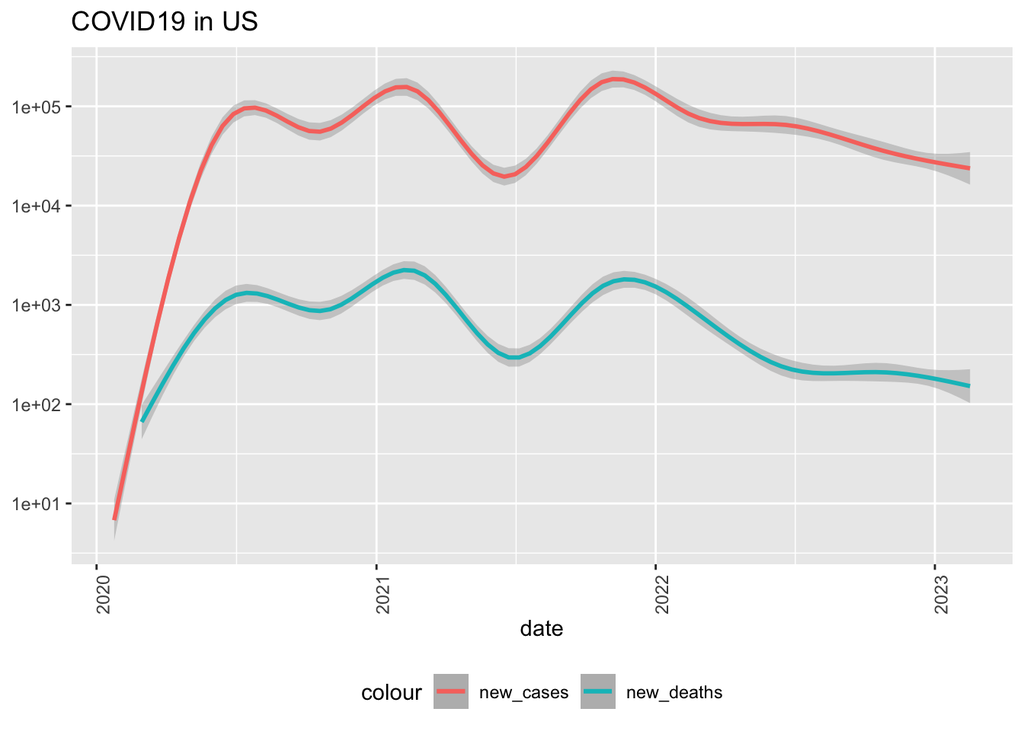

```r
US_totals %>%
  ggplot (aes(x = date, y = new_cases)) +
  geom_smooth(aes (color = "new_cases")) +
  geom_smooth(aes (y = new_deaths, color = "new_deaths")) +
  scale_y_log10() +
  theme (legend.position="bottom", axis.text.x = element_text(angle = 90)) +
  labs (title = "COVID19 in US", y= NULL)
```

Secondly, we look at the the states with lowest and highest Covid-19 fatality rates.

#### Visualization 2: States with the lowest COVID-19 deaths per thousands of population

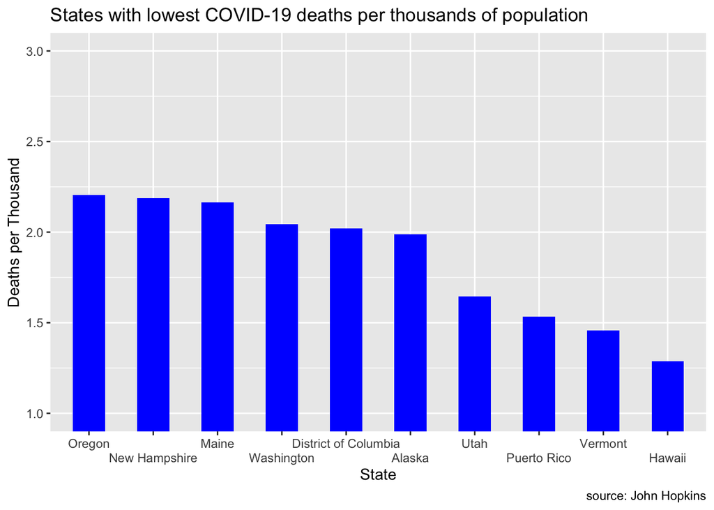

```r
ggplot(min_states[4:13,], aes(x=reorder(Province_State, -deaths_per_thou), y=deaths_per_thou)) +
  geom_bar(stat="identity", width=.5, fill="blue") + coord_cartesian(ylim = c(1, 3)) +
  labs(title="States with lowest COVID-19 deaths per thousands of population",
       caption="source: John Hopkins") + xlab("State") + ylab("Deaths per Thousand") + scale_x_discrete(guide = guide_axis(n.dodge = 2))
```

```r
  theme(axis.text.x = element_text(angle=65, vjust=0.6))
```

[output not shown]

#### Visualization 3: States with the highest COVID-19 deaths per thousands of population

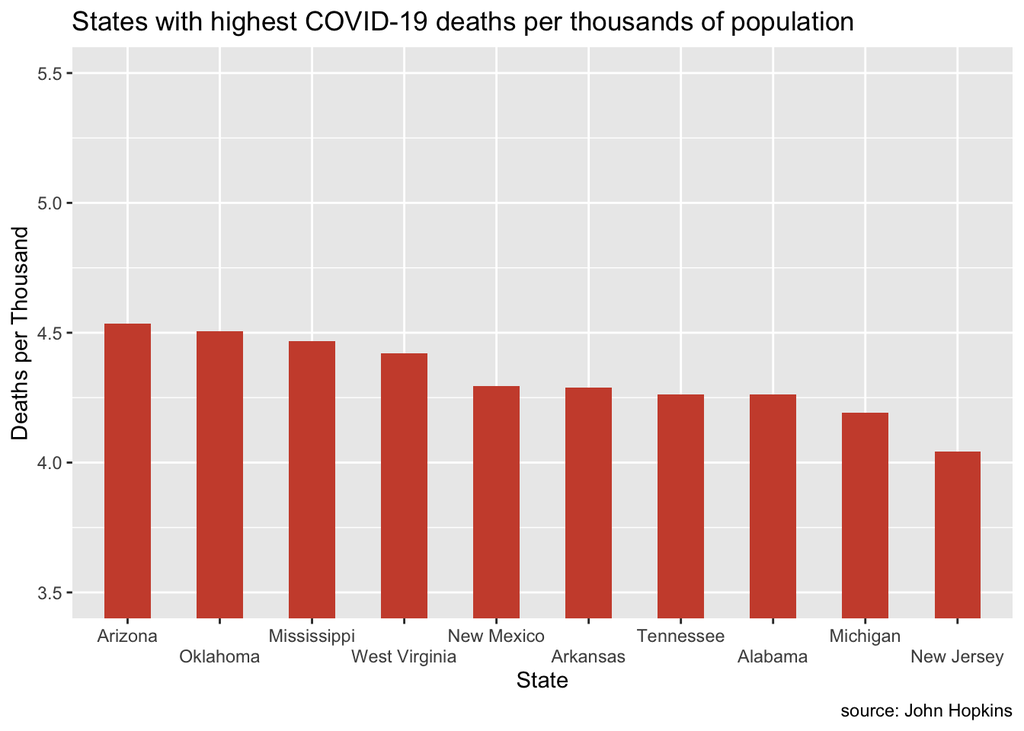

```r
ggplot(max_states, aes(x=reorder(Province_State, -deaths_per_thou), y=deaths_per_thou)) +
  geom_bar(stat="identity", width=.5, fill="tomato3") + coord_cartesian(ylim = c(3.5, 5.5)) +
  labs(title="States with highest COVID-19 deaths per thousands of population",
       caption="source: John Hopkins") + xlab("State") + ylab("Deaths per Thousand") + scale_x_discrete(guide = guide_axis(n.dodge = 2))
```

```r
  theme(axis.text.x = element_text(angle=65, vjust=0.6))
```

[output not shown]

Thirdly, we look at the specific trends in Hawaii where there is the lowest rate of fatality and in Arizona where there is the highest rate of fatality.

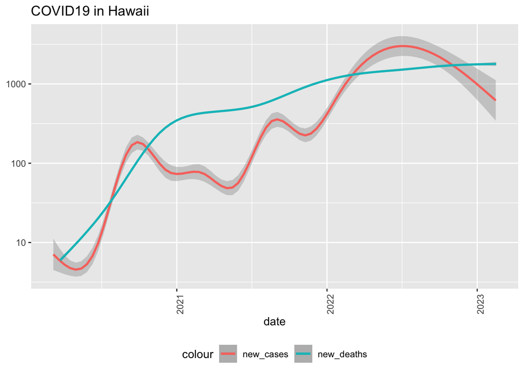

```r
state <- "Hawaii"
US_by_state %>%
  filter (Province_State==state) %>%
  filter (cases > 0) %>%
  ggplot (aes(x = date, y = new_cases)) +
  geom_smooth(aes (color = "new_cases")) +
  geom_smooth(aes (y = deaths, color = "new_deaths")) +
  scale_y_log10() +
  theme (legend.position="bottom", axis.text.x = element_text(angle = 90)) +
  labs(title= str_c("COVID19 in ", state), y= NULL)
```

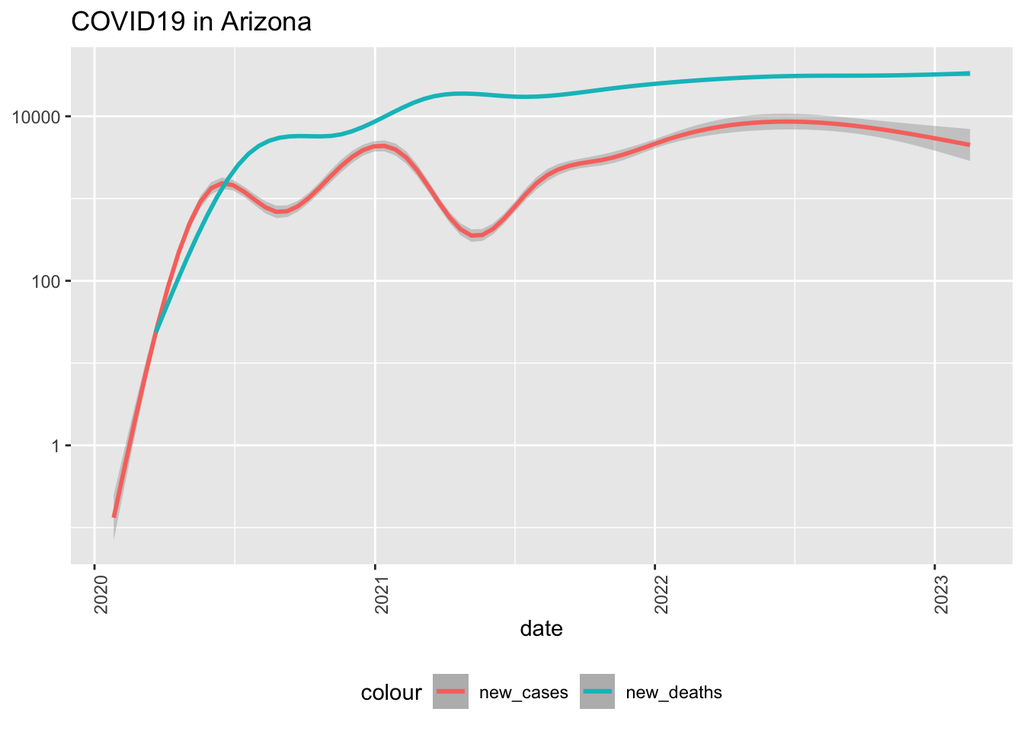

```r
state <- "Arizona"
US_by_state %>%
  filter (Province_State==state) %>%
  filter (cases > 0) %>%
  ggplot (aes(x = date, y = new_cases)) +
  geom_smooth(aes (color = "new_cases")) +
  geom_smooth(aes (y = deaths, color = "new_deaths")) +
  scale_y_log10() +
  theme (legend.position="bottom", axis.text.x = element_text(angle = 90)) +
  labs(title= str_c("COVID19 in ", state), y= NULL)
```

## Data Modelling and Analysis

### Question of Interest

Looking at the visualizations of states with the lowest and highest fatality rates, I can’t help but wonder what are the factors behind such discrepancies. What makes a state more or less susceptible to a higher death rate for Covid-19? One of the possible explanation could be population density, as it is commonly believed that urban centers with high concentration of people and movements might lead to higher transmission rates and ultimately higher fatality rates. My question of interest will explore the relationship (if any) between a state’s population density and its Covid-19 fatality rate.

#### Data model 1: Population Density vs. Fatality Rate: Reality and Prediction

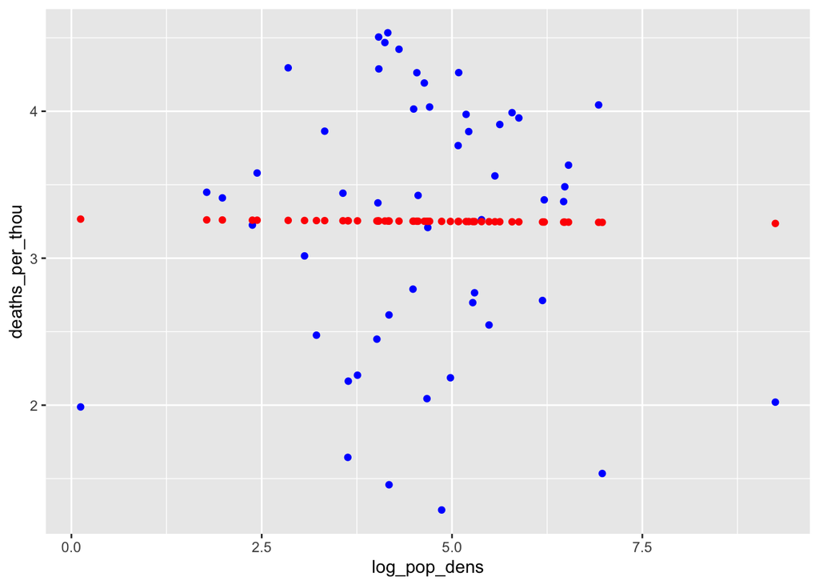

```r
US_tot_w_pred2 %>%
  ggplot() +
  geom_point(aes(x=log_pop_dens, y=deaths_per_thou), color = "blue") +
  geom_point(aes(x=log_pop_dens, y=pred), color = "red")
```

Ones can observe that the prediction is poor in its ability to correctly situate the actual data points. The graph shows no significant relationship between population density and fatality rate.

Below is another visualization of the relationship between population density and fatality rate. Here we have the Pearson correlation coefficient is approximately zero. Hence, the conclusion is that there is no significant relationship between a state’s population density and its fatality rate.

#### Data Model 2

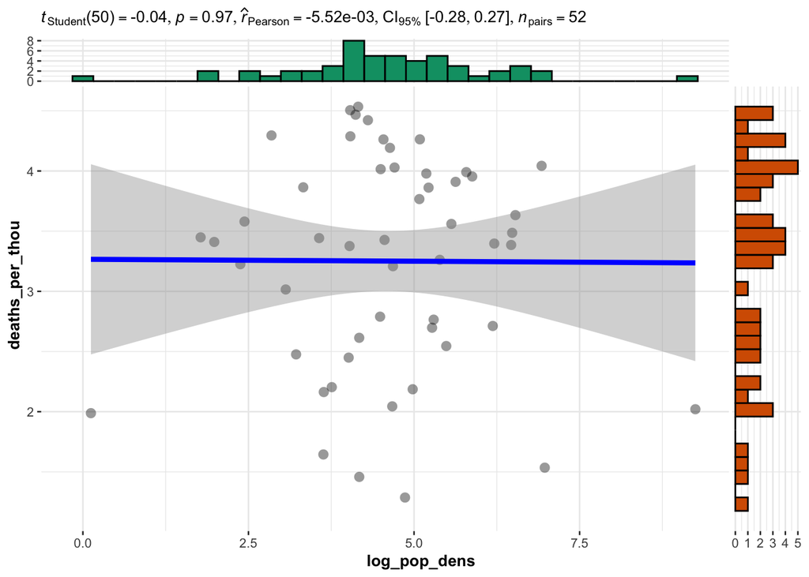

```r
ggscatterstats(
  data = US_state_totals3,
  x = log_pop_dens, y = deaths_per_thou,
  bf.message = FALSE)
```

### Conclusion

In conclusion, a state’s population density does not seem to explain its Covid-19 fatality rate. However, this conclusion is not final as there might be selection bias in this analysis. For instance, ones might use a different parameter instead of population density, such as the amount of people living in urban areas vs. rural areas, or the amount of people living under 30 minute away from a downtown central core, as this might better reflect the question of interest. Hence, further research must be carried out to answer questions regarding the differences in US states’ Covid-19 fatality.